# A/B TEST

## INFERENCES

```
Dalam A/B TEST, tujuan utama adalah untuk membanding 2 produk baik versi website, nama campaign, dan lain-lain sehingga kita bisa mengetahui yang mana dari 2 produk tersebut performanya lebih baik. Untuk mewujudkan hal tersebut, inference statistik mengakomodir itu dengan menggunakan data mentah yang kita punya
```

```python
print(kumpul.dtypes)
```

```
Campaign Name           object
Date                    object
Spend [USD]              int64
# of Impressions       float64
Reach                  float64
# of Website Clicks    float64
# of Searches          float64
# of View Content      float64
# of Add to Cart       float64
# of Purchase          float64
dtype: object
```

```python
print(kumpul[kumpul['Campaign Name']=='Control Campaign'].describe())
```

```
       Spend [USD]  # of Impressions          Reach  # of Website Clicks  \
count    30.000000         30.000000      30.000000            30.000000
mean   2288.433333     109688.766667   88936.066667          5317.566667
std     367.334451      21323.406299   21458.434279          1726.894156
min    1757.000000      71274.000000   42859.000000          2277.000000
25%    1945.500000      95191.250000   75300.250000          4122.250000
50%    2299.500000     113430.000000   91579.000000          5224.000000
75%    2532.000000     121259.000000  101958.750000          6609.500000
max    3083.000000     145248.000000  127852.000000          8137.000000

       # of Searches  # of View Content  # of Add to Cart  # of Purchase
count      30.000000          30.000000         30.000000      30.000000
mean     2226.933333        1945.133333       1301.300000     522.066667
std       851.582905         764.057171        400.434518     181.854040
min      1001.000000         848.000000        442.000000     222.000000
25%      1629.250000        1249.000000        942.500000     375.500000
50%      2390.000000        1984.000000       1339.000000     501.000000
75%      2655.000000        2360.500000       1638.000000     663.250000
max      4891.000000        4219.000000       1913.000000     800.000000
```

[output not shown]

1. Mebandingkan 2 grup test dan control untuk variabel continous

```
ada 2 metode jika data nya bertipe continous:
t-test dan Mann-Whitney U Test: Jika anda ingin membandingkan 2 variabel means pada A/B test,  t-test tepat digunakan jika data berdistribusi normal . jika tidak, the Mann-Whitney U test (a non-parametric alternative) dapat digunakan. sebelum kita cek hubungan antara kedua grup, kita harus memenuhi asumsi sebagai syarat dari metode yang akan digunakan
```

**Cek Asumsi**

- Normality

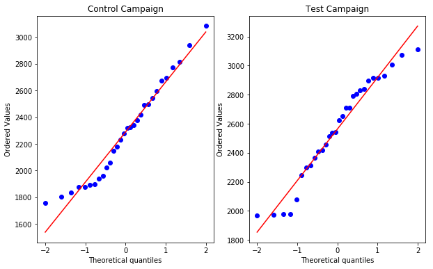

```python
#cek normalitas control dan test Campaign
from matplotlib import pyplot as plt
import scipy.stats as stats
fig,ax=plt.subplots(1,2,figsize=(10,6))
camp=['Control Campaign','Test Campaign']
for i,j in zip(range(2),camp):
    con=kumpul[kumpul['Campaign Name']==j]
    stats.probplot(con['Spend [USD]'],dist='norm',plot=ax[i])
    ax[i].set_title(j)
```

```
dari gambar diatas baik control campaign dan test campaign variabel Spen [USD] persebaran datanya berdistribusi normal. Ciri-ciri data berdistribusi normal pada qq plot adalah data point berada sekitar garis sedangkan ciri-ciri data skewed adalah data point menjauh dari garis
```

- independence, baik variabel spend control dan test campaign bersifat independen karena tidak saling mempengaruhi

```
Karena dat berdistribusi normal, independent, dan data bertipe kontinyu maka kita akan menggunakan t-test. T-test ada 2 cara yang pertama independent t-test dan paired t-test (membandingkan means dari 1 grup namun beda waktu atau kondisi). Kita menggunakan independent t-test karena ingin membandingkan means dari 2 produk berbeda.
```

```python
#perfor t test
import scipy.stats as stats
spend_con=kumpul[kumpul['Campaign Name']=='Control Campaign']['Spend [USD]']
spend_test=kumpul[kumpul['Campaign Name']=='Test Campaign']['Spend [USD]']
t_stat,p_value=stats.ttest_ind(spend_con,spend_test)
print(t_stat,p_value)
```

```
-2.9699915165656674 0.004326251207113227
```

```
Interpretation
Jika p value kurang dari nilai signifikansi yang diguanakan yaitu 0.05, kita dapat menolak hipotesis null dan menyimpulkan bahwa ada perbedaan means secara signifikan dari kedua grup
Jika p value lebih dari nilai signifikansi, kita tidak dapat menolak hipotesis null maka tidak ada perbedaan yang signifikan antara kedua grup
```

**Kesimpulanya karena p value 0.004326251207113227 atau kurang dari 0.05 maka ada perbedaan yang signifikan means variabel Spend [USD] antara control dan test campaign, kemudian t_stat hasilnya -2.9699915165656674 negatif artinya means dari control grup variabel spend lebih rendah dari means dari test campaign**

1. membadingkan kedua grup untuk variabel diskrit

```
Biasanya diskrit menggunakan proporsi sebagai alat untuk inference statistik, namun kali ini kita juga akan membandingkan mean (rata-rata) variabel diskrit antara 2 variabel. kita juga akan menggunakan proporsi setelah ini
```

- cek asumsi
1. normalitas, sample size >=30 selalu distribusi normal karena teorama limit pusat, artinya data memenuhi untuk asumsi ini
2. independece, antara 2 grup ini independent tidak saling mempengaruhi

```
untuk Discrete Variables:
1. Chi-squared Test atau Fisher’s Exact Test: These tests are used to examine whether distributions of categorical variables differ from one another. Given the small sample size, Fisher’s Exact Test might be particularly appropriate as it provides exact p-values for small sample sizes and is suitable when you have categorical data in a 2x2 table.
```

Proportion Tests (z-test): If you are comparing two proportions (e.g., conversion rates), this test can be applicable. However, with small sample sizes, ensure the assumptions of the z-test are not violated.

- membandingkan variabel diskrit dari 2 grup berdasarkan means

```python
kol=datacon.columns.tolist()[3:]
datahasil={}
for i in kol:
    li=[]
    for j in campaign:
        ambil=kumpul[kumpul["Campaign Name"]==j][i]
        urut=ambil.sort_values()
        li.append(urut)
    control=li[0]
    test=li[1]
    t_stat, p_value = stats.ttest_ind(control, test)
    datahasil[i]=p_value

result=pd.DataFrame.from_dict(datahasil,orient='index',columns=['P_values'])
result['hasil']=result['P_values'].apply(lambda x :'signifikansi' if x < 0.05 else 'not significant')
print(result)
```

```
                     P_values            hasil
# of Impressions     0.000006     signifikansi
Reach                0.000001     signifikansi
# of Website Clicks  0.112485  not significant
# of Searches        0.265817  not significant
# of View Content    0.624584  not significant
# of Add to Cart     0.000059     signifikansi
# of Purchase        0.986984  not significant
```

```
Dari tabel di atas, variabel of impression, reach, dan add to chart signifikansi artinya ada perbedaan means secara signifikan antara control dan test. Sedangkan website click, searches, view content, dan purchase tidak signifikansi artinya tidak ada perbedaan means antara control dan test
```

- membandingkan variabel diskri dari 2 grup menggunakan proporsi

```
    Untuk mengubah beberapa variabel diskit menjadi proporsi kita akan menghitung CTR (Click Through Rate) dan Conversion Rate. CTR adalah seberapa sering pengguna melakukan click setelah melihatnya, digunakan untuk mengukur seberapa efektifnya iklan dipasang. Conversion rate digunakan mengukur dalam persen pengguna melakukan tindakan setelah melihat iklan, mengunjungi website, campaign misal dengan membeli barang, log in, atau mengisi form
```

```
Rumus CTR dan Conversion Rate
```

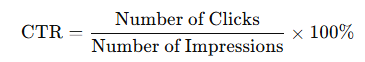

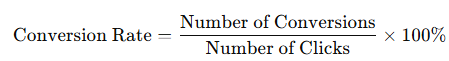